# Cryptocurrency Analysis

Damien Fleminks

21/11/2020

### install and setup packages

```r
#  rvest for web scraping
#  -> install.packages('rvest')
library(rvest)

#  tidyverse & gridExtra for data manipulation & visualization
#  -> install.packages("tidyverse")
#  -> install.packages("gridExtra")
library(tidyverse)
library(gridExtra)

# httr & jsonlite for rest api
#  -> install.packages("httr")
#  -> install.packages("jsonlite")
require("httr")
require("jsonlite")

#  rlist to extend list functions
#  -> install.packages("rlist")
library(rlist)
```

### Web scraping and data cleanup

Use coinranking.com to get top 50 cryptocurrency coins and retrieve the ticker symbol, coin name & current market cap

```r
crypto.url <- read_html("https://coinranking.com/")

crypto.tickers <- crypto.url %>%
  html_nodes(".profile__subtitle") %>%
  html_text()

crypto.name <- crypto.url %>%
  html_nodes(".profile__link") %>%
  html_text()

crypto.market.cap<- crypto.url %>%
  html_nodes(".valuta") %>%
  html_text()
```

Clean up the strings by removing unused characters and split into separate vectors

```r
crypto.tickers <- str_trim(str_remove_all(crypto.tickers, "\n"))
crypto.name <- str_trim(str_remove_all(crypto.name, "\n"))
crypto.unit.price <- crypto.market.cap[c(TRUE,FALSE)]
crypto.market.cap <- crypto.market.cap[c(FALSE,TRUE)]
```

Convert to correct data types and track which market cap price uses price unit in billion so we can multiply all output into units of million

```r
crypto.isbil <-  str_detect(crypto.market.cap,"billion")
crypto.unit.price <-  as.numeric(gsub("[^0-9.]", "", crypto.unit.price))

# find billion values and change them into million units
crypto.market.cap <- as.numeric(gsub("[^0-9.]", "", crypto.market.cap))
for(i in 1:length(crypto.isbil)){
     if(crypto.isbil[i]){
         crypto.market.cap[i] <- crypto.market.cap[i] * 1000
     }
}

# Create data frame of scraped and formatted data
crypto.currencies <- data.frame(Cryptocurrency = crypto.name, Ticker = crypto.tickers, Price=crypto.unit.price, market.cap = crypto.market.cap)
```

We now have a cleaned up Data frame with currency data that was taken from coinranking.com. We will use this data to retrieve historical price data from an api.

```r
print(
  head(crypto.currencies)
)
```

```
##   Cryptocurrency Ticker      Price market.cap
## 1        Bitcoin    BTC 18635.6400     345720
## 2       Ethereum    ETH   579.0400      65390
## 3            XRP    XRP     0.4709      20760
## 4     Tether USD   USDT     1.0000      18500
## 5      Chainlink   LINK    14.9600       5840
## 6       Polkadot    DOT     5.7400       5830
```

### Get historical price data from REST API

With the data collected from the web we will retrieve historical pricing data from api.tiingo.com API, we will start by by setting up the URL to execute a GET request. An account with API token is needed from api.tiingo.com, I requested a free token which had a limit of 20K requests a day which should be more then enough.

```r
#  Setting up base URL for cryptocurrency price history API
api.base <- "https://api.tiingo.com/tiingo/crypto/prices"

# Set currency used for pricing cryptocurrencies
api.currency <- "usd"

#  Retrieve history for top 5 cryptocurrencies, using the tickers from our cryptocurrency data frame
api.tickers <- paste(crypto.currencies$Ticker[1:5],"usd",sep="")
api.tickers <- paste(api.tickers, collapse = ',')
# Start date to retrieve prices in YYYY-MM-DD format, set 1 year from today
api.startdate <- as.POSIXlt(Sys.Date())
api.startdate$year <- api.startdate$year-1
api.startdate <- as.Date(api.startdate)

# set the frequency in which you want data resampled
api.resampleFreq = "1day"

# API token for authentication  (A free token can be requested at: api.tiingo.com, but you can use mine for now)
api.token = "20b7879009ee4863aef6a4dfd06fb50fb9ea447e"

# Combine variables into GET URL
api.call <- paste(api.base, "?tickers=",api.tickers,"&startDate=",api.startdate,"&resampleFreq=",api.resampleFreq,"&token=",api.token,sep='')
```

Make GET request with the request URL and store response in variable, we will convert the result into JSON and clean up the data and format it into a usuable format for our analysis.

```r
api.prices <- GET(api.call)

#  Format response to JSON
api.prices_text <- content(api.prices, "text")
api.prices_json <- fromJSON(api.prices_text, flatten = TRUE)
api.prices_df <- as.data.frame(api.prices_json)

#  Create a single data frame with formatted data for easier data visualization and  correct data types

returnNewDf <- function(index){

  #  Get coin and store dataframe
  temp.coin <- api.prices_df$baseCurrency[index]
  temp.df <- api.prices_df[index,][[4]][[1]]

  # Get length and store coin name as new column
  temp.rownumber <- length(temp.df[,1])
  temp.df$coin <- rep(c(temp.coin),each=length(temp.rownumber))
  temp.df$date <- as.Date(temp.df$date)

  #  To calculate the price value of max in terms of percentage add new column with percentages of close
  temp.df$price.percentage <- temp.df$close/max(temp.df$close)

  return(temp.df)
}

#  Add first data frame, then loop to add the rest
crypto.all <- returnNewDf(1)
for(i in 1:length(api.prices_df[,1])) {
  crypto.all <- rbind(
    crypto.all,returnNewDf(i)

  )
}
```

Now we can access all coins from the same data frame with the different unique coins, looking at the head of 2 examples

```r
unique(crypto.all[c('coin')])
```

```
##      coin
## 1     btc
## 735   eth
## 1102 link
## 1469  xrp
```

```r
print(
  head(filter(crypto.all, coin=='btc'))
)
```

```
##        low volumeNotional    volume    close tradesDone       date     high
## 1 6789.516     1926759603 264916.06 7273.095    1467982 2019-11-22 7740.099
## 2 7085.834      685172609  93667.83 7314.919     880636 2019-11-23 7347.067
## 3 6866.461      902009319 130564.87 6908.515     985197 2019-11-24 7334.276
## 4 6558.107     1000408572 140553.85 7117.618     831091 2019-11-25 7380.515
## 5 7019.760      906684482 126669.17 7157.894     950329 2019-11-26 7341.017
## 6 6846.524     1386814970 184592.22 7512.857    1145003 2019-11-27 7660.460
##       open coin price.percentage
## 1 7629.049  btc        0.3888811
## 2 7271.272  btc        0.3911174
## 3 7315.614  btc        0.3693875
## 4 6912.365  btc        0.3805680
## 5 7111.498  btc        0.3827215
## 6 7158.775  btc        0.4017008
```

```r
print(
  head(filter(crypto.all, coin=='eth'))
)
```

```
##        low volumeNotional    volume    close tradesDone       date     high
## 1 138.0231      395874292 2645192.7 149.6580     614794 2019-11-22 162.8990
## 2 146.2309      150877255  993382.7 151.8823     344831 2019-11-23 154.3683
## 3 138.7638      176914758 1263634.9 140.0046     373356 2019-11-24 152.9081
## 4 132.2192      220073330 1509434.6 145.7985     354700 2019-11-25 151.6285
## 5 143.5751      173533014 1176393.3 147.5128     343863 2019-11-26 149.9392
## 6 140.9853      245946815 1611067.2 152.6608     430905 2019-11-27 155.5658
##       open coin price.percentage
## 1 161.0769  eth        0.2594942
## 2 149.7460  eth        0.2633510
## 3 151.8828  eth        0.2427561
## 4 140.0701  eth        0.2528022
## 5 145.7911  eth        0.2557745
## 6 147.5251  eth        0.2647008
```

### Visualizing the data

We can analyze the price of the coins over time to see how they have performed over the past year.

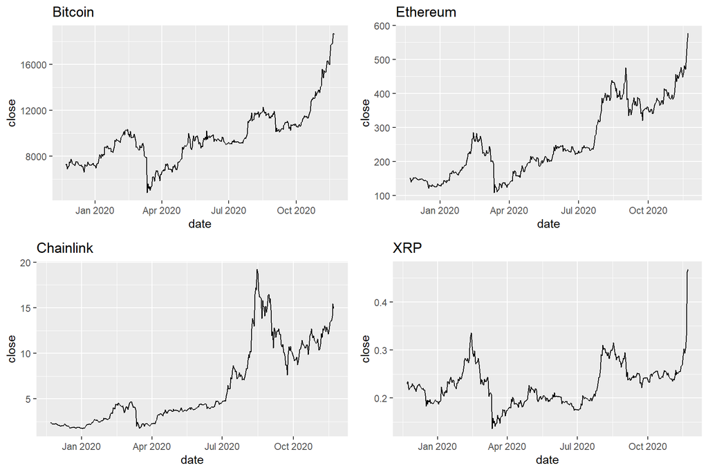

```r
# Plot a line graph for all coin prices
cPrice1 <- ggplot(filter(crypto.all, coin=='btc'), aes(x=date,y=close)) + geom_line() + ggtitle("Bitcoin")
cPrice2 <- ggplot(filter(crypto.all, coin=='eth'), aes(x=date,y=close)) + geom_line() + ggtitle("Ethereum")
cPrice3 <- ggplot(filter(crypto.all, coin=='link'), aes(x=date,y=close)) + geom_line() + ggtitle("Chainlink")
cPrice4 <- ggplot(filter(crypto.all, coin=='xrp'), aes(x=date,y=close)) + geom_line() + ggtitle("XRP")
grid.arrange(cPrice1 , cPrice2, cPrice3, cPrice4, nrow = 2)
```

As we have added an extra column to compare the percentage of the price to the max price we can compare how all coins compared relatively from each other in terms of price fluctation.

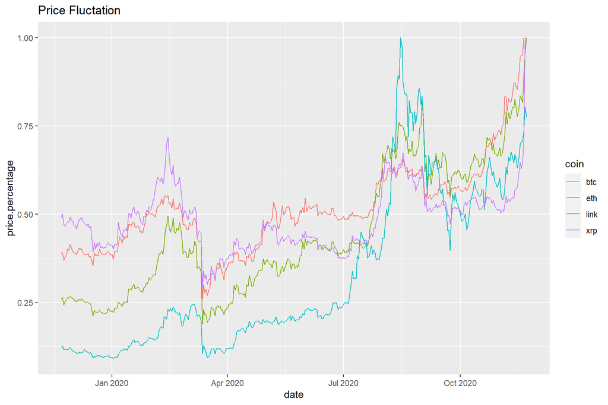

```r
# Compare the different coins on the percentage growth
ggplot(crypto.all, aes(x=date,y=price.percentage)) + geom_line(aes(color=coin)) + ggtitle("Price Fluctation")
```

From the tradesDone and volumeNotional column we can analyze the number of transitions and total volume in USD traded, we will compare the results and look at the daily trend over the year and the total numbers.

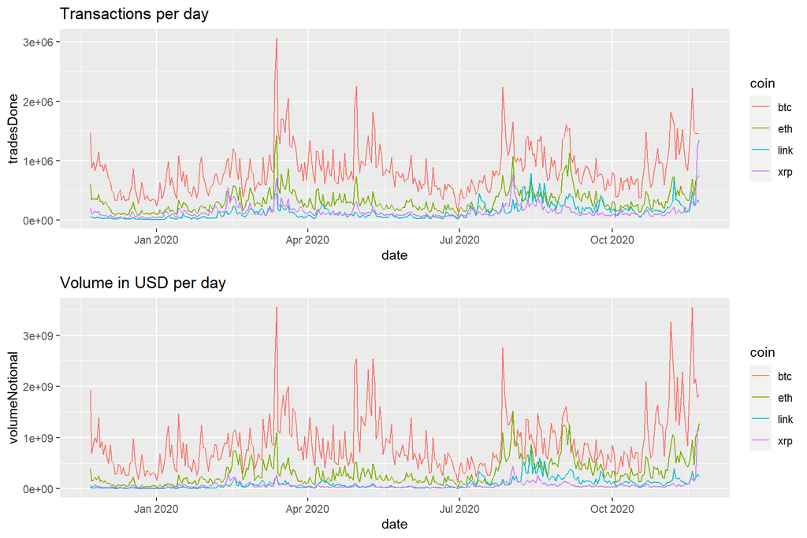

```r
# Compare  frequency & volume in USD of trades over the last year

cTradeComp <- ggplot(crypto.all, aes(x=date,y=tradesDone)) + geom_line(aes(color=coin))  + ggtitle("Transactions per day")
cVolComp <- ggplot(crypto.all, aes(x=date,y=volumeNotional)) + geom_line(aes(color=coin))  + ggtitle("Volume in USD per day")
grid.arrange(cTradeComp , cVolComp, nrow = 2)
```

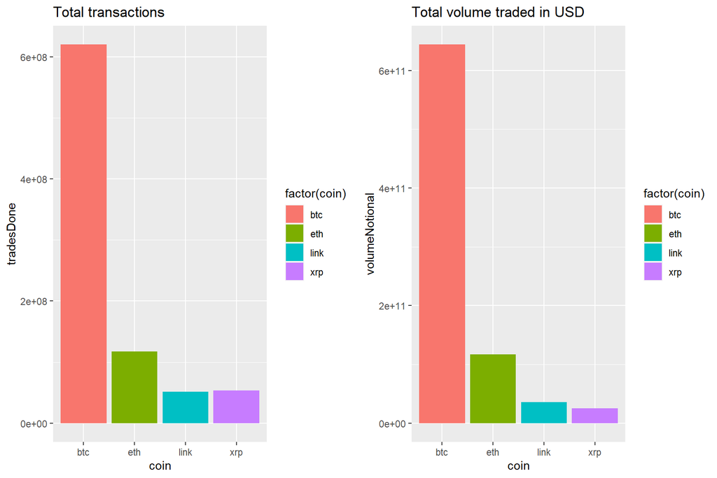

```r
# Compare total frequency & volume of trade

cTradeTotal <-ggplot(crypto.all) + geom_bar(aes(y=tradesDone, x=coin, fill=factor(coin)), stat="identity")  + ggtitle("Total transactions")
cVolTotal <- ggplot(crypto.all) + geom_bar(aes(y=volumeNotional, x=coin, fill=factor(coin)), stat="identity") + ggtitle("Total volume traded in USD")
grid.arrange(cTradeTotal , cVolTotal, nrow = 1)
```